# Piece_3

Benjamin Egan

2025-02-21

## Monte Carlo Simulation - Brown M&Ms

As part of my responsibility as a TA for the PSY 312 course, I am responsible for the execution of lab exercises designed to aid in comprehension of topics learned during lecture. To help students understand probability, sampling, and the creation of a distribution of sample means, we did the “M&M Lab.”

In the M&M lab, students discovered that Mars, Inc. does not distribute the colors evenly within a bag of plain M&Ms. This depends upon which of two packaging plants (Cleveland or New Jersey) made the product.

The back half of the lab has students run through a Monte Carlo Simulation to create a distribution of sample means using only brown M&Ms. Students are asked to create three samples with 1, 9, and 25 observations. We then plot them on a graph and see how the distribution looks.

### The problem

This normally works since there are 18 students, but Workday made it so my lab has only 9. To counteract this, I went in an manually simulated the other 9 students. Doing this was a pain, and I wanted to write a script that would do this for me.

## The Solution

```r
brown <- read_spss("Brown_M&Ms_2025.sav")
tibble(brown)
```

```
## # A tibble: 300 × 1
##    brownmms
##       <dbl>
##  1        7
##  2       11
##  3       10
##  4       10
##  5        2
##  6        3
##  7       10
##  8       20
##  9       11
## 10       10
## # ℹ 290 more rows
```

In the data set, each value represents the number of brown M&Ms in a packet. There are 300 “packets” in the data set. I created histograms below.

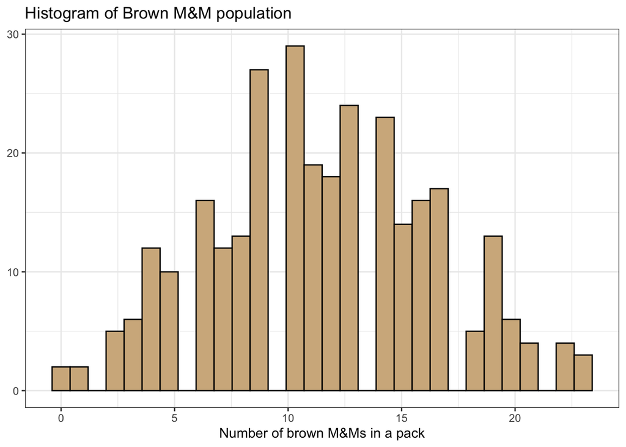

```r
brown %>%
  ggplot(aes(
    x = brownmms
  ))+
  geom_histogram(color = "black", fill = "tan")+
  theme_bw()+
  labs(
    x = "Number of brown M&Ms in a pack",
    y = NULL,
    title = "Histogram of Brown M&M population"
  )
```

I wanted to add in the number of observations in each variable. Here was the first attempt (Thanks to this forum https://stackoverflow.com/questions/24198896/get-values-and-positions-to-label-a-ggplot-histogram for helping me out)

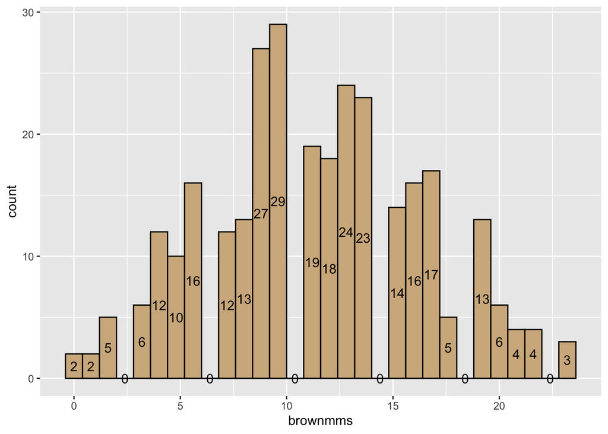

```r
brown %>%
  ggplot(aes(brownmms)) +
  geom_histogram(binwidth=.8, fill = "tan", color = "black") +
  stat_bin(binwidth=.8, geom='text', color='black', aes(label=..count..),
           position=position_stack(vjust = .5))
```

I asked chat if I could improve upon this graph. Here’s what it helped me spit out. It told me that ggplot2 uses these dot-surrounded variable names (..varname..) to indicate computed aesthetics that don’t exist in the original dataset but are created during the plotting process. In this code, ..count.. is a special variable created by geom_histogram(stat = “bin”). It represents the number of observations (frequency) in each bin.

Here is what chat spit out, with the exception that I took out the specification of bin width.

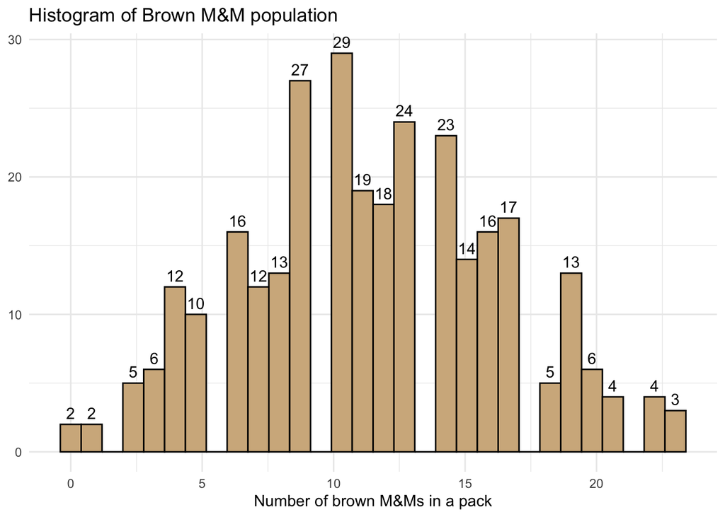

```r
brown %>%
  ggplot(aes(x = brownmms)) +
  geom_histogram(fill = "tan", color = "black") +
  geom_text(stat = "bin",aes(label = ifelse(..count.. > 0, ..count.., "")),
            vjust = -0.5, color = "black") +
  theme_minimal()+
  labs(
    x = "Number of brown M&Ms in a pack",
    y = NULL,
    title = "Histogram of Brown M&M population"
  )
```

```r
mean(brown$brownmms)
```

```
## [1] 11.52333
```

```r
sd(brown$brownmms)
```

```
## [1] 4.967734
```

Here we can see that the “population” of brown M&Ms is fairly spread out(sd = 4.96), and centered around 11.5.

### Monte Carlo simulation

The first step is to get a sample of 1.

```r
set.seed(1234)
sample(x = brown$brownmms, size = 1)
```

```
## [1] 10
```

```r
#use replicate() to get multiple of them
```

By using the sample() function, I am able to randomly sample 1 packet from the 300. For replication purposes, I set the seed so I know that i will always get the same numbers. This time I got 10, representing the average number of brown M&Ms in a packet with a sample size of 1.

I can also change the size of my sample.

```r
set.seed(1234)
sample_9_once <- sample(x = brown$brownmms, size = 9)
sample_25_once <- sample(x = brown$brownmms, size = 25)

mean(sample_9_once)
```

```
## [1] 9.111111
```

```r
mean(sample_25_once)
```

```
## [1] 12.24
```

I replicated the samples but increased my sample sizes. In the lab, we asked students to find the mean of each sample and record it.

### Replication

It would be pointless to copy and paste the lines of code 27 times to simulate 9 students obtaining three samples. So instead, I used repeat() to do this for me.

```r
set.seed(1234)
number <- 1

repeat {
sample(x = brown$brownmms, size = 1) %>%
  print()
   number <- number + 1
   if(number >3) {
      break
   }}
```

```
## [1] 10
## [1] 3
## [1] 15
```

Here I was able to create a sample with size 1, and repeat this function three times, simulating one person. Since I don’t need to distinguish between participants, I can do it 27 times, creating a list.

```r
set.seed(1234)
number_size1 <- 1

repeat {
sample(x = brown$brownmms, size = 1) %>%
  print()
   number_size1 <- number_size1 + 1
   if(number_size1 >27) {
      break
   }}
```

```
## [1] 10
## [1] 3
## [1] 15
## [1] 16
## [1] 10
## [1] 5
## [1] 12
## [1] 9
## [1] 2
## [1] 16
## [1] 16
## [1] 16
## [1] 10
## [1] 14
## [1] 5
## [1] 16
## [1] 16
## [1] 12
## [1] 13
## [1] 8
## [1] 22
## [1] 11
## [1] 13
## [1] 11
## [1] 10
## [1] 14
## [1] 14
```

Now we need to replicate this with sample sizes of 9 and 25. Copy and pasting the code while changing the code provides us with a problem. It’s printing out each number in the sample and not providing us with the mean of the sample.

```r
set.seed(1234)
number_size9_wrong <- 1
repeat {
sample(x = brown$brownmms, size = 9) %>%
  print()
   number_size9_wrong <- number_size9_wrong + 1
   if(number_size9_wrong >27) {
      break
   }}
```

```
## [1] 10  3 15 16 10  5 12  9  2
## [1] 16 16 16 10 14  5 16 16 12
## [1] 13  8 22 11 13 11 10 14 13
## [1]  9  2  6 16 18 11 12 13 19
## [1]  9  5 14 17  6  7  5 17 13
## [1]  9 10 17 10 13  7 11 14 14
## [1] 10 20 10 20 17  5  9 10 15
## [1] 14 10  9  3  9  8 12  9 14
## [1] 15  9  4 10  4 10 21 10  6
## [1] 14 23  8  4 13 15 16  7  5
## [1] 15 12 13 13  9  2 12 13 20
## [1]  9 18  7 10 10  3 13 18 19
## [1]  1  7  8  4  9  6 22  7 10
## [1]  7 12 15 14  4  6 14 16  2
## [1]  4 13  4 17 13 11  3  4 10
## [1] 12 18 19 18 19  9  5 23 16
## [1]  8  7 13 16  6 14  4 17  1
## [1]  8 13  6  6 22  7 14  7 17
## [1] 10 14 11  5 22 17 12 14  8
## [1] 12  8 13 15 12 13  6 15 10
## [1]  3  9 11 11  6  9 16 17 10
## [1] 16  2 17  3  5  4 11 12 13
## [1]  4 10 13 16  0 13  3  5  9
## [1] 13 13 10 19 20  9 19  2 18
## [1] 15 10  5 10  2  7 13 13 12
## [1]  9 13  6 12 15 22 21  6 12
## [1] 17  9 13  8 11  9 12 12 15
```

To fix this, I piped the sample function inside of mean() before piping into print.

```r
set.seed(1234)
size9_repeat <- 1
repeat {
sample(x = brown$brownmms, size = 9) %>%
    mean() %>%
  print()
   size9_repeat <- size9_repeat + 1
   if(size9_repeat > 27) {
      break
   }}
```

```
## [1] 9.111111
## [1] 13.44444
## [1] 12.77778
## [1] 11.77778
## [1] 10.33333
## [1] 11.66667
## [1] 12.88889
## [1] 9.777778
## [1] 9.888889
## [1] 11.66667
## [1] 12.11111
## [1] 11.88889
## [1] 8.222222
## [1] 10
## [1] 8.777778
## [1] 15.44444
## [1] 9.555556
## [1] 11.11111
## [1] 12.55556
## [1] 11.55556
## [1] 10.22222
## [1] 9.222222
## [1] 8.111111
## [1] 13.66667
## [1] 9.666667
## [1] 12.88889
## [1] 11.77778
```

Finally I can apply what I’ve learned to the sample size of 25.

```r
set.seed(1234)
size25_repeat <- 1
repeat {
sample(x = brown$brownmms, size = 25) %>%
    mean() %>%
  print()
   size25_repeat <- size25_repeat + 1
   if(size25_repeat > 27) {
      break
   }}
```

```
## [1] 11.64
## [1] 11.6
## [1] 11.08
## [1] 11.56
## [1] 10.08
## [1] 11.72
## [1] 11.6
## [1] 9.24
## [1] 11.28
## [1] 12.96
## [1] 12.16
## [1] 13.04
## [1] 11.68
## [1] 12.84
## [1] 11.68
## [1] 12.92
## [1] 13.72
## [1] 11.88
## [1] 12.12
## [1] 11.28
## [1] 10.6
## [1] 11.08
## [1] 11.28
## [1] 12.16
## [1] 11.72
## [1] 11.96
## [1] 12.04
```